# Ch. 5: Distribution of White Suckers

Kurt Riggin

2025-05-01

## Question: How does temperature and erosivity impact the distribution of White Suckers across Northeastern United States?

## Methods:

Data was taken from 2018-2019 NRSA rivers and streams dataset and cleaned to include environmental site, fish abundance, and reference condition data for the *Catostomidae* family. Only reference sites were used for analysis and was parititioned into sites used for construction (C) and sites used for validation (V). An equivalent dataframe was also created, changing fish abundance to presence/absence for analysis. Preliminary inspection of relationships between abundance, occurance and covariates were performed using GLMs and temperature and erosivity were selected for analysis as they would potentially influence trait data in following chapters.

```r
#### GLMs to explore white sucker presence and temperature/erosivity
tempoccurance <- glm(white.sucker ~ ws_temp, data = data_C, family = binomial(link = 'logit'))
# summary(tempoccurance)

erodoccurance <- glm(white.sucker ~ erod_ws, data = data_C, family = binomial(link = 'logit'))
# summary(erodoccurance)
```

White suckers were chosen as the single species to model due to their wide range across sites with varying environmental covariate values. A single species distribution model was then built using the Hmsc package following the framework from Chapter 5 of *Joint Species Distribution Modelling with Applications in R* by Ovaskainen and Abrego. Longitude and latitude coordinates of sites was used as a spatial random effect and a probit model for occurance data was selected due to abundance data having poor MCMC convergence. MCMC was ran using the following parameters in the following code, and convergence was examined for both fixed and random effects using plots, effective sample size, and gelman’s diganostic.

```r
#### Setup model
XData <- data.frame(temp = data_C$ws_temp, erosion = data_C$erod_ws)

# select White Suckers to model (Catostomus commersonii)
Y <- as.matrix(data_C$white.sucker)
colnames(Y) <- "Catostomus_commersonii"
# bind together coordinates to include spatial random effect
latlong <- as.matrix(cbind(data_C$lat, data_C$long))


studyDesign <- data.frame(site_id = as.factor(data_C$SITE_ID))
rownames(latlong) <- studyDesign[,1]
rL <- HmscRandomLevel(sData = latlong)
XFormula <- ~ temp + erosion

# use probit model for occurrence data
model <- Hmsc(Y = Y, XData = XData, XFormula = XFormula, distr = "probit",
              studyDesign = studyDesign, ranLevels = list(site_id = rL))


# MCMC parameters
nChains = 2
samples = 1000
thin = 10
transient = 5000
verbose = 1000
nParallel = 2
# MCMC sampling with first fitting models in maximum-likelihood framework
# modelsample <- sampleMcmc(model, thin = thin, samples = samples, transient = transient,
#                            nChains = nChains, verbose = verbose, nParallel = nParallel,
#                           initPar = "fixed effects")

# MCMC evaluaion
# plot(modelpost$Beta) # convergence looks good
# effectiveSize(modelpost$Beta) # ESS relatively high
# gelman.diag(modelpost$Beta, multivariate = FALSE)$psrf # relatively close to 1
# summary(modelpost$Beta)
```

Explanatory power of the model was measured using AUC and Tjur R-squared, and gradient plots for model predictions were constructed. Posterior occurrence probabilities were calculated for validation reference sites to test model prediction, and accuracy was assessed using a threshold of 0.5 for presence/absence.

```r
#### Predict distribution in validation sites
latlong.grid <- as.matrix(cbind(data_V$lat, data_V$long))
XData.grid <- data.frame(temp = data_V$ws_temp, erosion = data_V$erod_ws)
Gradient.grid <- prepareGradient(modelsample, XDataNew = XData.grid,
                                 sDataNew = list(site_id = latlong.grid))
predYnr <- predict(modelsample, Gradient = Gradient.grid)


# posterior occurrence probability for each site
EpredY <- as.data.frame(apply(abind(predYnr, along = 3), c(1,2), mean))
EpredY$SITE_ID <- data_V$SITE_ID
posteriordata <- data_V %>% select(SITE_ID, lat, long, ws_temp, erod_ws, white.sucker) %>% left_join(EpredY, by = "SITE_ID")
posteriordata$white.sucker <- ifelse(posteriordata$white.sucker == 1, "present", "absent")
names(posteriordata)[names(posteriordata) == 'white.sucker'] <- 'observed'
names(posteriordata)[names(posteriordata) == 'Catostomus_commersonii'] <- 'post.prob'


# accuracy of model predictions
posteriordata$predicted <- ifelse(posteriordata$post.prob >= 0.5, "present", "absent")
posteriordata$correct <- posteriordata$predicted == posteriordata$observed
# mean(posteriordata$correct)
```

## Results:

Upon preliminary analysis using GLMs, temperature showed a significant (p = 0.000737) negative relationship with white sucker presence, and erosivity had a similar result (p = 0.000443). Upon MCMC convergence, posterior estimates of beta parameters for temperature and erosivity were also negative, with over 95% of the posterior distribution below zero. The mean value for the temperature beta parameter was -0.2183 and the mean value for erosivity was -23.9539.

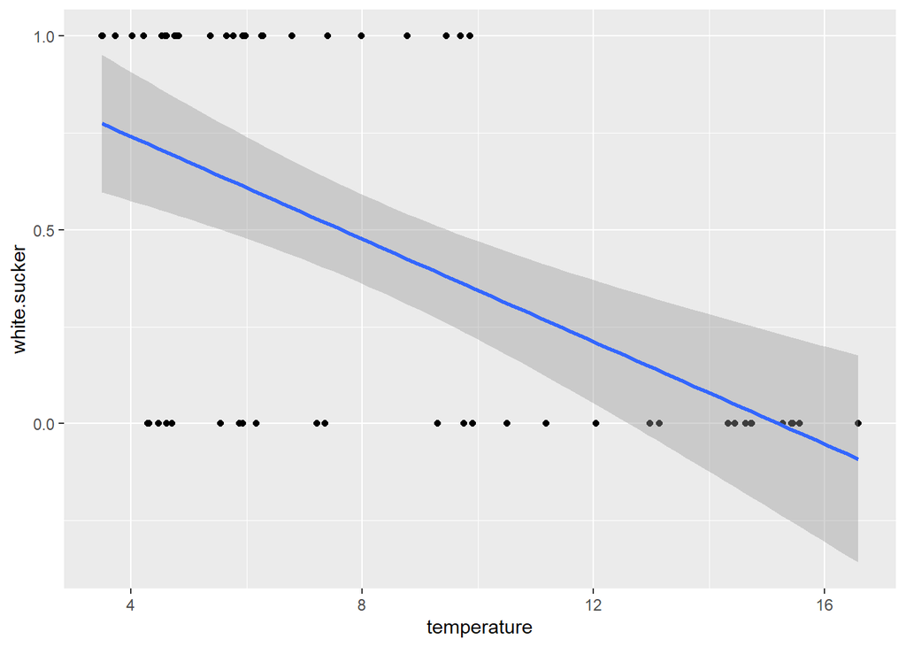

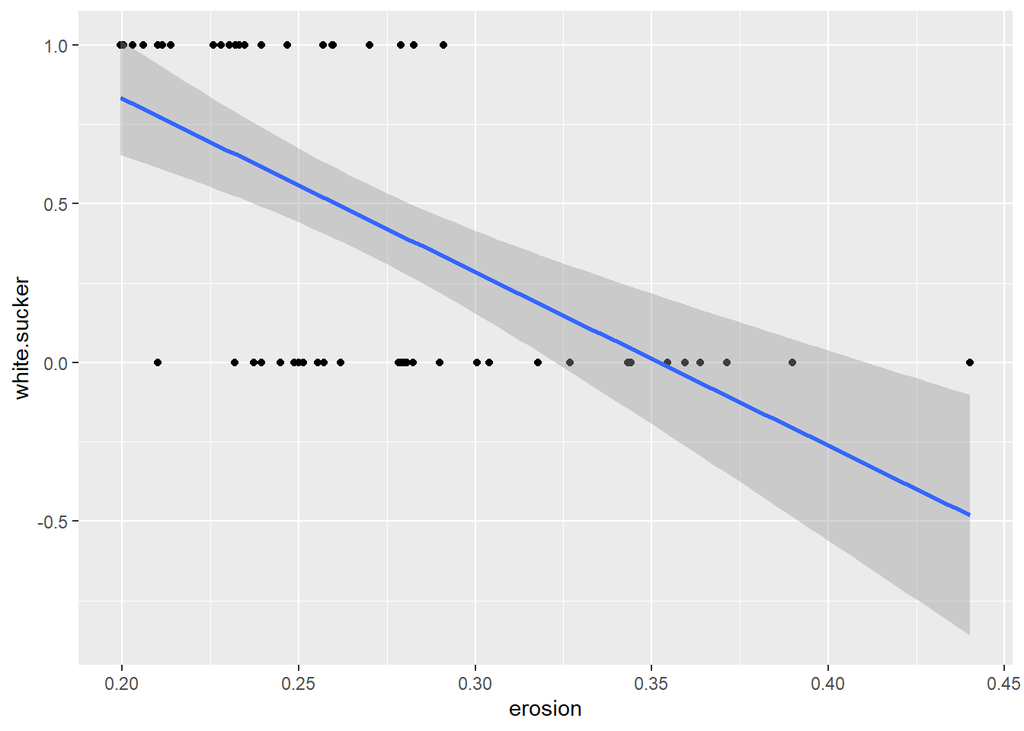

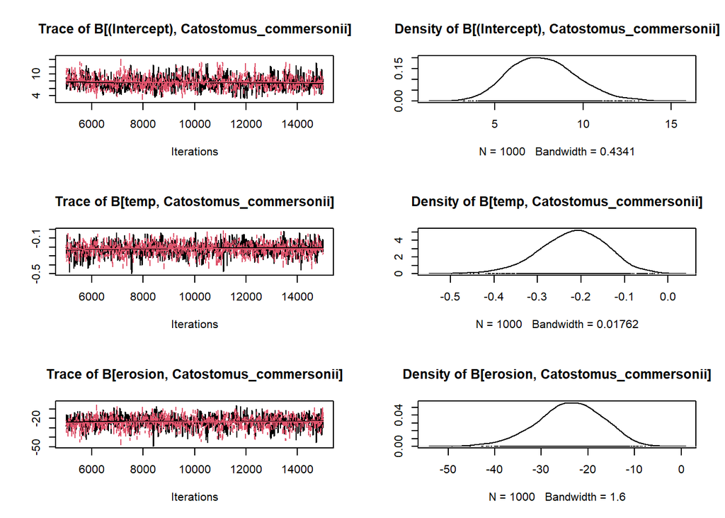

MCMC convergence of the alpha parameter for spatial random effect was not satisfactory, which could potentially be explained due to the large distance between sites. However, explanatory power of the model with respect to the construction data was relatively high, with an AUC value of 0.915 and a Tjur R-squared value of 0.515. The gradient plots constructed for model predictions once again assigned a negative relationship between both temperature and erosivity on the presence of White Suckers.

```
## [1] 0
```

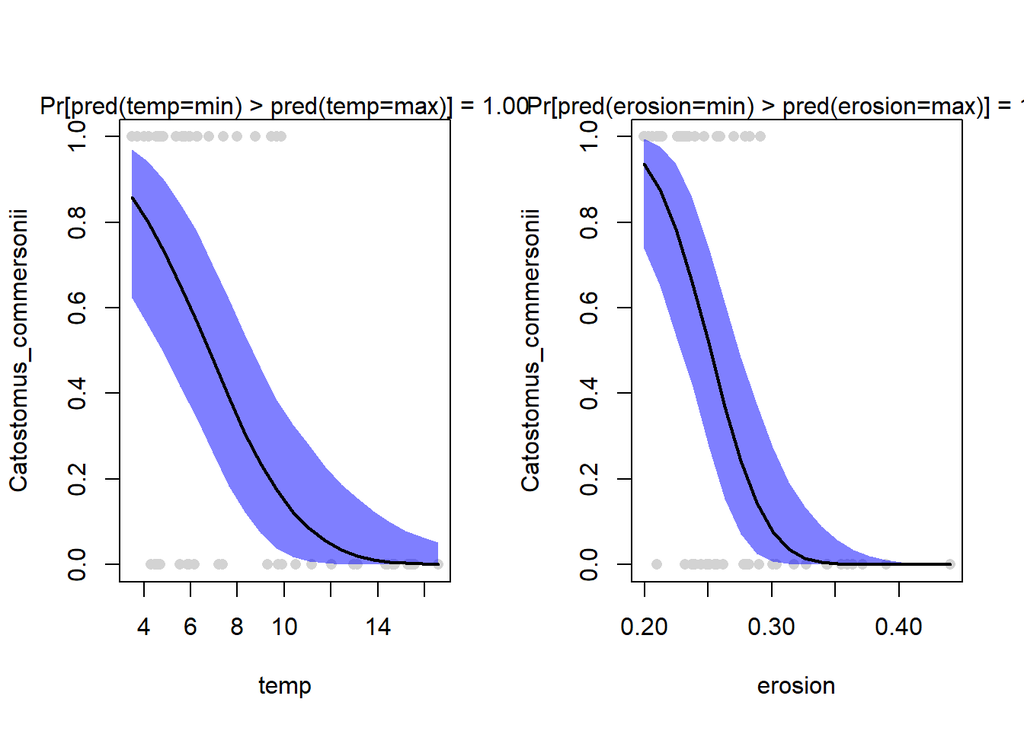

```
## [1] 0
```

Finally, across validation reference sites, the model predicted presence/absence of White Suckers with 65% accuracy.

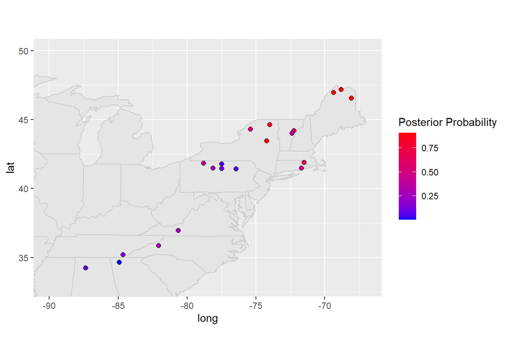

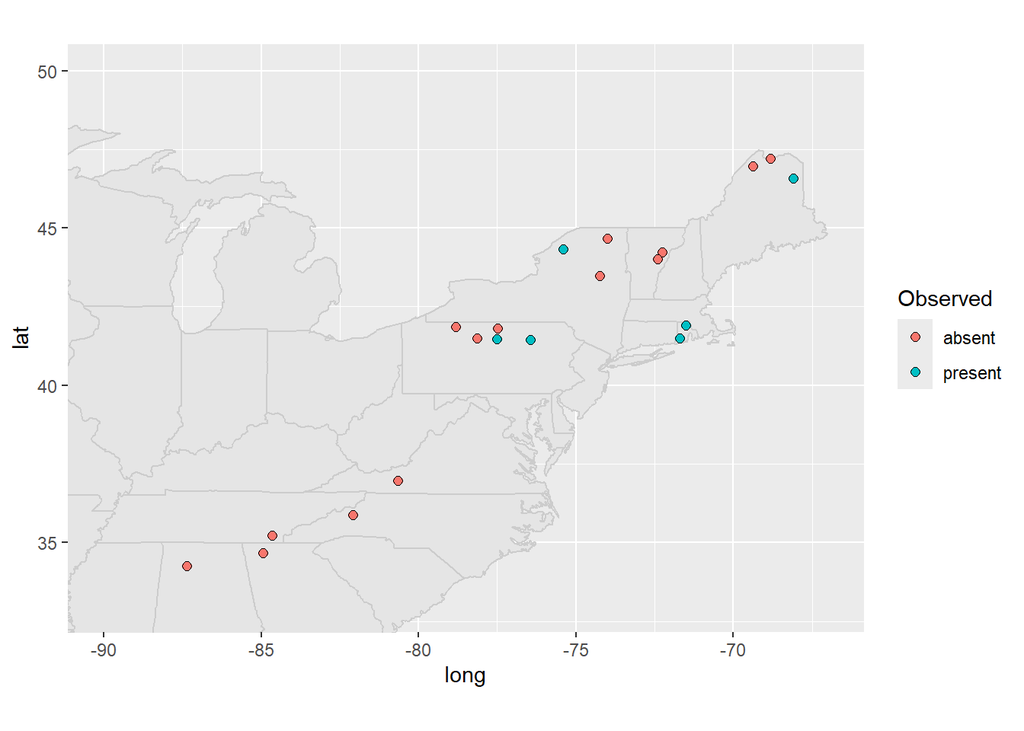

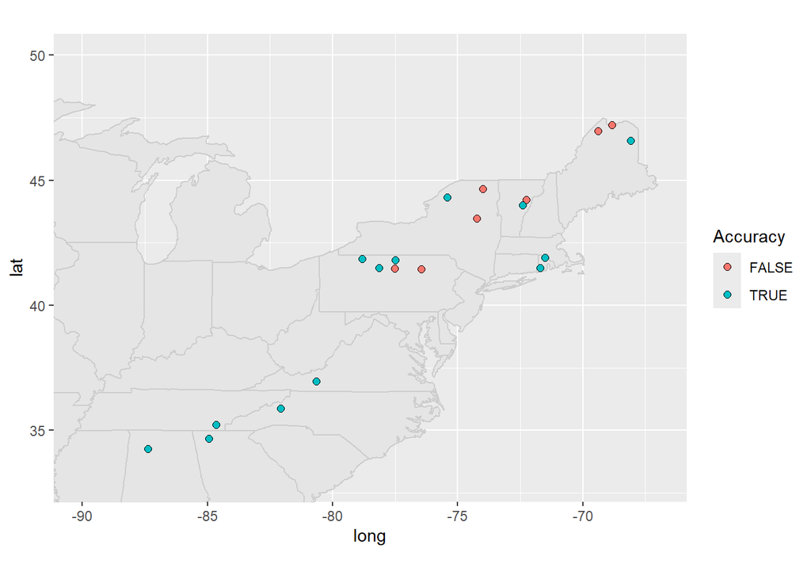

## Challenges:

Some of the main challenges of this analysis was the non-satisfactory convergence of MCMC with the initial abundance data. This could possibly be due to a number of factors, as there were many instances of 0 counts of species found at sites. Upon the first preliminary analysis, elevation was used as the environmental covariate, however the units of the data were wrong, which was fixed relatively quickly. MCMC convergence of the alpha parameter spatial effect was not satisfactory, and will not be used in subsequent analysis.